# Studying hierarchical models with informative priors

Steve Simon

April 5, 2017

```r
getRversion()
```

```
## [1] '3.3.3'
```

```r
Sys.time()
```

```
## [1] "2017-04-09 21:27:51 CDT"
```

```r
library(broom)
library(dplyr)
```

```r
library(ggplot2)
library(magrittr)
library(rstan)
rstan_options(auto_write = TRUE)
options(mc.cores = parallel::detectCores())
```

I wanted to fit a series of Bayesian models starting with a very simple model and moving to more complex models. I read in both enrollment data sets, and I made a totally unjustified change by converting the NAs to zeros. It’s easy to modify these models to account for the NAs (which represent, I assume, the weeks when a center was not yet through all the approvals needed to get started). In any case, I chose the sixth row of the second data set (csp558) as the place to test these models.

```r
f <- "csp546 enrollment.csv"
csp546 <- read.csv(file=f, stringsAsFactors=FALSE, header=TRUE)

csp546a <- csp546
csp546a[is.na(csp546a)] <- 0
csp546a$Z <- apply(csp546a, 1, sum)
csp546b <- as.data.frame(sapply(csp546a, cumsum))
csp546b$t <- 1:(dim(csp546b)[1])
csp546b
```

```
##     A  B  C  D  E  F  G  H  I  J  K  L  M  N   Z  t
## 1   0  0  0  0  0  0  0  0  1  1  0  0  0  0   2  1
## 2   0  0  0  0  0  0  2  0  3  2  3  0  0  0  10  2
## 3   1  1  1  0  1  5  2  0  3  4  6  0  1  0  25  3
## 4   1  1  3  0  2 11  3  0  3  5  9  0  2  0  40  4
## 5   1  1  3  0  2 12  7  0  3  7 11  0  2  0  49  5
## 6   2  1  4  0  3 14  8  0  4  8 17  0  2  0  63  6
## 7   4  2  5  0  4 17 10  0  4 11 21  0  7  0  85  7
## 8   5  3  5  0  4 19 13  0  6 14 22  0 11  0 102  8
## 9   7  3  7  0  5 20 15  0  8 16 25  0 13  0 119  9
## 10 10  5 10  0  6 23 18  0  8 18 27  0 20  0 145 10
## 11 10  6 12  0  9 24 18  0 10 20 33  0 21  0 163 11
## 12 11  7 14  0 10 27 20  0 12 22 36  0 23  0 182 12
## 13 12  8 15  0 11 27 21  0 12 23 40  0 25  0 194 13
## 14 14  9 17  0 11 28 22  1 12 25 41  0 27  0 207 14
```

[output cut: 42 more lines]

```r
f <- "csp558 enrollment.csv"
csp558 <- read.csv(file=f, stringsAsFactors=FALSE, header=TRUE)

csp558a <- csp558
csp558a[is.na(csp558a)] <- 0
csp558a$Z <- apply(csp558a, 1, sum)
csp558b <- as.data.frame(sapply(csp558a, cumsum))
csp558b$t <- 1:(dim(csp558b)[1])
csp558b
```

```
##     A  B  C  D   Z  t
## 1   1  3  0  0   4  1
## 2   2  5  0  0   7  2
## 3   3  7  4  2  16  3
## 4   3  7  5  3  18  4
## 5   3  9  7  5  24  5
## 6   5 12 10  8  35  6
## 7   7 12 11 10  40  7
## 8   7 15 12 13  47  8
## 9   7 15 13 15  50  9
## 10 10 16 14 16  56 10
## 11 11 18 15 17  61 11
## 12 12 18 16 19  65 12
## 13 12 20 17 21  70 13
## 14 14 21 17 22  74 14
## 15 14 22 17 24  77 15
## 16 16 24 18 25  83 16
## 17 16 25 18 27  86 17
## 18 18 27 20 28  93 18
## 19 20 27 21 30  98 19
## 20 20 29 21 30 100 20
## 21 22 29 24 31 106 21
## 22 23 31 24 33 111 22
## 23 23 35 25 35 118 23
## 24 27 37 27 36 127 24
```

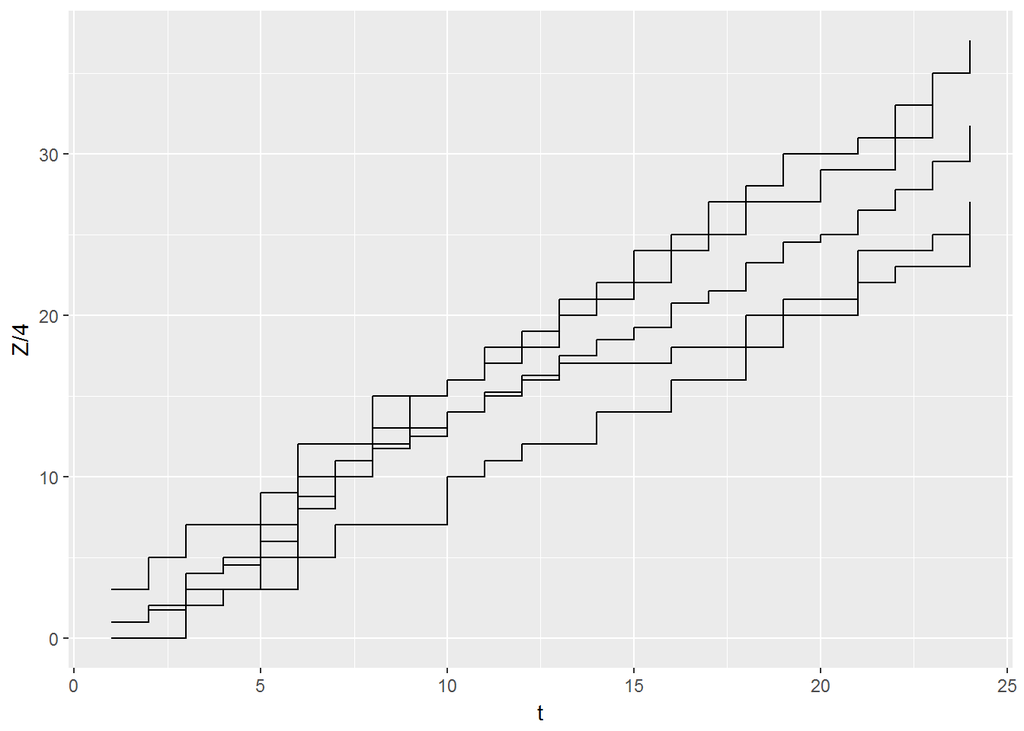

```r
library(ggplot2)
ggplot(csp558b, aes(t, Z/4)) +
  geom_step() +
  geom_step(aes(t,A)) +
  geom_step(aes(t,B)) +
  geom_step(aes(t,C)) +
  geom_step(aes(t,D))
```

Just to repeat, I want to use the sixth row of the second data set. The prior belief is that it will take 24 weeks to accumulate 200 patients. The researcher choose a prior distribution corresponding to 50% of the total sample size, or a gamma(100, 12).

```r
# recall what the values are for week 6 and week 24.
csp558b[c(6, 24), ]
```

```
##     A  B  C  D   Z  t
## 6   5 12 10  8  35  6
## 24 27 37 27 36 127 24
```

## Part 1

The first model ignores the center effect completely.

## Non-informative prior

Start with a non-informative prior.

Since you have gone 1/4 of the way into the study and have 35 patients, the simple extrapolation is that you will have about 35*4 or 140 patients at the end of the study. The accrual rate (lambda) should be close to 35/6 or 5.83.

```r
f <- "mod01.stan"
# Here's what's hiding in the file
cat(readLines(f), sep="\n")
```

```
## data {
##   int<lower=0>           n;    // current sample size (overall)
##   real<lower=0>          t;    // current time
##   int<lower=0>           N;    // planned sample size
##   real<lower=0>          T;    // planned time
##   real<lower=0, upper=1> P;    // strength of prior
## }
## parameters {
##   real<lower=0> lambda;        // single rate for each center
## }
## model {
##   lambda ~ gamma(N*P, T*P);
##   n ~ poisson(lambda*t);
## }
## generated quantities {
##   real<lower=0> ntilde;
##   ntilde = n + poisson_rng(lambda*(T-t));
## }
```

```r
# Here's the data. P=1/200 gives a prior weight of one subject.
dat <- list(n=35, t=6, N=200, T=24, P=1/200)
fit01 <- stan(file=f, data=dat)
tidy(fit01)
```

```
##     term   estimate  std.error
## 1 lambda   5.893552  0.9819753
## 2 ntilde 141.092000 20.4757747
```

## Informative prior, too optimistic

Change this to an informative prior. This prior has a weight equal to 1/2 the total sample size (100). This prior distribution is too optimistic, at least relative to the data we’ve seen so far. The prior rate is 100/12 = 8.33 which is a lot higher than the rate observed in the data (35/6 or 5.83). The posterior mean is going to be a weighted average of the prior rate and the rate calculated from the data with about 3/4 of the weight being given to the prior or roughly 7.7.

```r
# Here's the data. Changing S to 0.5 produces an informative prior.
dat <- list(n=35, t=6, N=200, T=24, P=0.5)
fit01a <- stan(file=f, data=dat)
tidy(fit01a)
```

```
##     term   estimate  std.error
## 1 lambda   7.519982  0.6569742
## 2 ntilde 170.816500 16.7195608
```

```r
tidy(fit01)
```

```
##     term   estimate  std.error
## 1 lambda   5.893552  0.9819753
## 2 ntilde 141.092000 20.4757747
```

## Informative prior, more realistic

Try a different informative prior. This prior has the same weight as before (100), but this time the prior rate (100/18 = 5.5) is not too much different from the data. When you compare the estimated rate (lambda) from this informative prior to the non-informatative prior, you should notice a change not in the mean, but in the standard error.

```r
f <- "mod01.stan"
# Here's the data. Increasing T is equivalent
# to setting a slower accrual rate.
dat <- list(n=35, t=6, N=200, T=36, P=0.5)
fit01b <- stan(file=f, data=dat)
tidy(fit01b)
```

```
##     term   estimate  std.error
## 1 lambda   5.629273  0.4999755
## 2 ntilde 204.164500 20.0044616
```

```r
tidy(fit01a)
```

```
##     term   estimate  std.error
## 1 lambda   7.519982  0.6569742
## 2 ntilde 170.816500 16.7195608
```

```r
tidy(fit01)
```

```
##     term   estimate  std.error
## 1 lambda   5.893552  0.9819753
## 2 ntilde 141.092000 20.4757747
```

## Part 2

Run this as a multi-center trial, but with no center effect. This is mathematically equivalent to a single center trial, but it’s worth running to verify that Stan gives the expected results.

## Non-informative prior

Start with a non-informative prior.

```r
f <- "mod02.stan"
# Here's what's hiding in the file
cat(readLines(f), sep="\n")
```

```
## data {
##   int<lower=0>           J;    // number of centers
##   int<lower=0>           n[J]; // current sample size in each center
##   real<lower=0>          t;    // current time
##   int<lower=0>           N;    // planned sample size overall
##   real<lower=0>          T;    // planned time
##   real<lower=0, upper=1> P;    // strength of prior
## }
## parameters {
##   real<lower=0> lambda;        // single common rate for each center
## }
## model {
##   lambda ~ gamma(N*P, T*P);
##   // gamma(N*P/J, T*P) also works but it weakens the prior.
##   for (j in 1:J) {
##     n[j] ~ poisson(lambda*t/J);
##   }
## }
## generated quantities {
##   real<lower=0> ntilde[J];
##   real<lower=0> ntilde_total;
##   for (j in 1:J) {
##     ntilde[j] = n[j] + poisson_rng(lambda*(T-t)/J);
##   }
##   ntilde_total = sum(ntilde);
## }
```

```r
# Here's the data. P=1/200 gives a prior weight of one subject.
dat <- list(J=4, n=c(5, 12, 10, 8), t=6, N=200, T=24, P=1/200)
fit02 <- stan(file=f, data=dat)
tidy(fit02)
```

```
##           term   estimate std.error
## 1       lambda   5.915194  0.990661
## 2    ntilde[1]  31.610750  6.832050
## 3    ntilde[2]  38.622500  6.780006
## 4    ntilde[3]  36.471000  6.830251
## 5    ntilde[4]  34.631500  6.896492
## 6 ntilde_total 141.335750 20.571736
```

```r
tidy(fit01)
```

```
##     term   estimate  std.error
## 1 lambda   5.893552  0.9819753
## 2 ntilde 141.092000 20.4757747
```

The results are identical to the earlier result (fit01) after allowing for a small Monte Carlo sampling error.

## Informative prior, too optimistic

Next with an overly optimistic informative prior.

```r
dat <- list(J=4, n=c(5, 12, 10, 8), t=6, N=200, T=24, P=0.5)
fit02a <- stan(file=f, data=dat)
tidy(fit02a)
```

```
##           term   estimate std.error
## 1       lambda   7.505832  0.638460
## 2    ntilde[1]  38.676250  6.442656
## 3    ntilde[2]  45.950750  6.543893
## 4    ntilde[3]  43.908000  6.503123
## 5    ntilde[4]  41.834250  6.498179
## 6 ntilde_total 170.369250 16.317934
```

```r
tidy(fit01a)
```

```
##     term   estimate  std.error
## 1 lambda   7.519982  0.6569742
## 2 ntilde 170.816500 16.7195608
```

These results are identical to fit01a.

## Informative prior, more realistic

Finally, look at a more realistic informative prior.

```r
dat <- list(J=4, n=c(5, 12, 10, 8), t=6, N=200, T=36, P=0.5)
fit02b <- stan(file=f, data=dat)
tidy(fit02b)
```

```
##           term   estimate std.error
## 1       lambda   5.617247  0.483181
## 2    ntilde[1]  47.067500  7.319654
## 3    ntilde[2]  54.182750  7.442594
## 4    ntilde[3]  51.942750  7.321023
## 5    ntilde[4]  50.109750  7.308526
## 6 ntilde_total 203.302750 19.066475
```

```r
tidy(fit01b)
```

```
##     term   estimate  std.error
## 1 lambda   5.629273  0.4999755
## 2 ntilde 204.164500 20.0044616
```

These results are identical to fit01b. These results re-assure us that Stan is behaving well, at least for these simple models.

## Part 3

Now allow each center to vary.

## Non-informative prior

Start first with a non-informative prior. The rate for the average center should be roughly 35/6 or 5.83, but the first center, with only 5 patients, should have the lowest rate and the second center, with 12 patients, should have the highest rate.

```r
f <- "mod03.stan"
# Here's what's hiding in the file
cat(readLines(f), sep="\n")
```

```
## data {
##   int<lower=0>           J;    // number of centers
##   int<lower=0>           n[J]; // current sample size in each center
##   real<lower=0>          t;    // current time
##   int<lower=0>           N;    // planned sample size overall
##   real<lower=0>          T;    // planned time
## }
## parameters {
##   real<lower=0> lambda[J];     // separate rate for each center
##   real<lower=0> alpha;         // parameters from hyperprior
##   real<lower=0> beta;          // parameters from hyperprior
## }
## transformed parameters {
##   real<lower=0> hyper_mn;
##   real<lower=0> hyper_cv;
##   hyper_mn = alpha / beta;
##   hyper_cv = 1/sqrt(alpha);
## }
## model {
##   alpha ~ gamma(1, 1);
##   beta  ~ gamma(1, 1);
##   for (j in 1:J) {
##     lambda[j] ~ gamma(alpha, beta);
##     n[j] ~ poisson(lambda[j]*t/J);
##   }
## }
## generated quantities {
##   real<lower=0> ntilde[J];
##   real<lower=0> ntilde_total;
##   real<lower=0> average_lambda;
##   average_lambda = sum(lambda) / J;
##   for (j in 1:J) {
##     ntilde[j] = n[j] + poisson_rng(lambda[j]*(T-t)/J);
##   }
##   ntilde_total = sum(ntilde);
## }
```

```r
dat <- list(J=4, n=c(5, 12, 10, 8), t=6, N=200, T=24)
fit03 <- stan(file=f, data=dat, control = list(adapt_delta = 0.99))
tidy(fit03, estimate.method="mean")
```

```
##              term    estimate  std.error
## 1       lambda[1]   3.8094295  1.4253222
## 2       lambda[2]   7.4131418  2.0628741
## 3       lambda[3]   6.3934819  1.9120829
## 4       lambda[4]   5.3295125  1.7365999
## 5           alpha   2.5692318  1.3429466
## 6            beta   0.4820008  0.2782121
## 7        hyper_mn   5.9660956  2.5834295
## 8        hyper_cv   0.6951025  0.2054000
## 9       ntilde[1]  22.1260000  7.6146976
## 10      ntilde[2]  45.3282500 10.9863632
## 11      ntilde[3]  38.7120000 10.1031963
## 12      ntilde[4]  31.8482500  9.2831981
## 13   ntilde_total 138.0145000 20.4880631
## 14 average_lambda   5.7363914  0.9970216
```

Now how do you incorporate an informative prior into a hierarchical setting? One way is to reparameterize the hyperprior.

## Informative prior, too optimistic

I have some serious reservations about this approach, but I’m inlcuding here because it might work if we could find the right tweaks.

Try this reparameterized model with the optimistic prior.

```r
f <- "mod03a.stan"
# Here's what's hiding in the file
cat(readLines(f), sep="\n")
```

```
## data {
##   int<lower=0>           J;    // number of centers
##   int<lower=0>           n[J]; // current sample size in each center
##   real<lower=0>          t;    // current time
##   int<lower=0>           N;    // planned sample size overall
##   real<lower=0>          T;    // planned time
##   real<lower=0, upper=1> P;    // strength of prior
## }
## parameters {
##   real<lower=0> lambda[J];     // separate rate for each center
##   real<lower=0> hyper_mn;      // parameters from hyperprior
##   real<lower=0> hyper_cv;      // parameters from hyperprior
## }
## transformed parameters {
##   real<lower=0> alpha;
##   real<lower=0> beta;
##   alpha = 1 / hyper_cv^2;         // hyper_cv = 1/sqrt(alpha)
##   beta = (hyper_cv^2 * hyper_mn); // hyper_mn = alpha / beta
## }
## model {
##   hyper_mn ~ gamma(N*P, T*P);
##   hyper_cv ~ gamma(1, 1);
##   lambda ~ gamma(alpha, beta);
##   for (j in 1:J) {
##     n[j] ~ poisson(lambda[j]*t/J);
##   }
## }
## generated quantities {
##   real<lower=0> ntilde[J];
##   real<lower=0> ntilde_total;
##   real<lower=0> average_lambda;
##   average_lambda = sum(lambda) / J;
##   for (j in 1:J) {
##     ntilde[j] = n[j] + poisson_rng(lambda[j]*(T-t)/J);
##   }
##   ntilde_total = sum(ntilde);
## }
```

```r
dat <- list(J=4, n=c(5, 12, 10, 8), t=6, N=200, T=24, P=0.5)
fit03a <- stan(file=f, data=dat)
tidy(fit03a, estimate.method="mean")
```

```
##              term    estimate   std.error
## 1       lambda[1]   4.4679956  1.40875414
## 2       lambda[2]   7.0841538  1.79070008
## 3       lambda[3]   6.3208898  1.63138171
## 4       lambda[4]   5.5915847  1.60804880
## 5        hyper_mn   8.3313963  0.84803501
## 6        hyper_cv   0.3808916  0.02567707
## 7           alpha   6.9859281  0.93009888
## 8            beta   1.2082656  0.16685488
## 9       ntilde[1]  25.1215000  7.61759442
## 10      ntilde[2]  43.7812500  9.88993686
## 11      ntilde[3]  38.3912500  9.13816447
## 12      ntilde[4]  33.1795000  8.95705515
## 13   ntilde_total 140.4735000 20.42476660
## 14 average_lambda   5.8661560  0.97888876
```

## Informative prior, more realistic

Now try it with the more realistic prior.

```r
dat <- list(J=4, n=c(5, 12, 10, 8), t=6, N=200, T=36, P=0.5)
fit03b <- stan(file=f, data=dat)
tidy(fit03b, estimate.method="mean")
```

```
##              term    estimate   std.error
## 1       lambda[1]   4.3449381  1.41377108
## 2       lambda[2]   7.1616204  1.82024123
## 3       lambda[3]   6.3487270  1.70509325
## 4       lambda[4]   5.5754097  1.57455676
## 5        hyper_mn   5.5719471  0.55963370
## 6        hyper_cv   0.4211877  0.03006219
## 7           alpha   5.7225098  0.80855860
## 8            beta   0.9884771  0.14199783
## 9       ntilde[1]  37.6660000 12.04183107
## 10      ntilde[2]  65.9237500 15.47364839
## 11      ntilde[3]  57.5837500 14.59284838
## 12      ntilde[4]  49.8127500 13.56855607
## 13   ntilde_total 210.9862500 32.25259863
## 14 average_lambda   5.8576738  0.97480860
```

# Part 4

You could also add a pseudo-center with parameters consistent with prior distribution.

## Informative prior, too optimistic

```r
f <- "mod04.stan"
# Here's what's hiding in the file
cat(readLines(f), sep="\n")
```

```
## data {
##   int<lower=0>           J;    // number of centers
##   int<lower=0>           n[J]; // current sample size in each center
##   real<lower=0>          t;    // current time
##   int<lower=0>           N;    // planned sample size overall
##   real<lower=0>          T;    // planned time
##   int<lower=0>           pseudo_n;
##   real<lower=0>          pseudo_t;
##   real<lower=0, upper=1> P;    // strength of prior
## }
## parameters {
##   real<lower=0> lambda[J+1];   // single common rate for each center
##   real<lower=0> alpha;         // parameters from hyperprior
##   real<lower=0> beta;
## }
## transformed parameters {
##   real<lower=0> hyper_mn;
##   real<lower=0> hyper_cv;
##   hyper_mn = alpha / beta;
##   hyper_cv = 1/sqrt(alpha);
## }
## model {
##   alpha ~ exponential(1.0);
##   beta ~ gamma(0.1, 1.0);
##   lambda ~ gamma(alpha, beta);
##   for (j in 1:J) {
##     n[j] ~ poisson(lambda[j]*t/J);
##   }
##   pseudo_n ~ poisson(lambda[J+1]*pseudo_t);
## }
## generated quantities {
##   real<lower=0> ntilde[J];
##   real<lower=0> ntilde_total;
##   real<lower=0> average_lambda;
##   average_lambda = 0;
##   for (j in 1:J) {
##     average_lambda = average_lambda + lambda[j]/J;
##     ntilde[j] = n[j] + poisson_rng(lambda[j]*(T-t)/J);
##   }
##   ntilde_total = sum(ntilde);
## }
```

```r
dat <- list(J=4, n=c(5, 12, 10, 8), t=6, N=200, T=24, pseudo_n=100, pseudo_t=12, P=0.5)
fit04a <- stan(file=f, data=dat, control = list(adapt_delta = 0.99))
tidy(fit04a, estimate.method="mean")
```

```
##              term    estimate  std.error
## 1       lambda[1]   3.9570166  1.5424010
## 2       lambda[2]   7.6810082  2.1369294
## 3       lambda[3]   6.6638444  2.0077841
## 4       lambda[4]   5.5504651  1.7341122
## 5       lambda[5]   8.2842917  0.8219073
## 6           alpha   2.2542331  1.2198374
## 7            beta   0.3454814  0.2128247
## 8        hyper_mn   7.4542702  3.3299244
## 9        hyper_cv   0.7478170  0.2285113
## 10      ntilde[1]  22.8632500  8.2001134
## 11      ntilde[2]  46.6422500 11.1827782
## 12      ntilde[3]  39.9820000 10.5780031
## 13      ntilde[4]  32.9925000  9.3434345
## 14   ntilde_total 142.4800000 20.4972592
## 15 average_lambda   5.9630836  0.9715028
```

## Informative prior, more realistic

```r
dat <- list(J=4, n=c(5, 12, 10, 8), t=6, N=200, T=36, pseudo_n=100, pseudo_t=18, P=0.5)
fit04b <- stan(file=f, data=dat, control = list(adapt_delta = 0.99))
tidy(fit04b, estimate.method="mean")
```

```
##              term    estimate  std.error
## 1       lambda[1]   3.8182955  1.4717948
## 2       lambda[2]   7.6200696  2.0824202
## 3       lambda[3]   6.5538342  1.9314727
## 4       lambda[4]   5.4903537  1.7498027
## 5       lambda[5]   5.5646219  0.5400819
## 6           alpha   2.2923295  1.2578236
## 7            beta   0.3886760  0.2442212
## 8        hyper_mn   6.7506911  3.1216224
## 9        hyper_cv   0.7427773  0.2305625
## 10      ntilde[1]  33.5757500 12.0826843
## 11      ntilde[2]  69.0485000 17.1328787
## 12      ntilde[3]  59.2347500 16.1537574
## 13      ntilde[4]  49.0080000 14.5526073
## 14   ntilde_total 210.8670000 31.5392928
## 15 average_lambda   5.8706382  0.9637721
```

# Part 5

Finally, you could look at a perturbation model. Here’s a perturbation model with a non-informative prior.

## Non-informative prior

```r
f <- "mod05.stan"
# Here's what's hiding in the file
cat(readLines(f), sep="\n")
```

```
## data {
##   int<lower=0>           J;    // number of centers
##   int<lower=0>           n[J]; // current sample size in each center
##   real<lower=0>          t;    // current time
##   int<lower=0>           N;    // planned sample size overall
##   real<lower=0>          T;    // planned time
##   real<lower=0, upper=1> P;    // strength of prior
## }
## parameters {
##   real<lower=0> lambda;        // overall rate for each center
##   real<lower=0> eta[J];        // deviation from overall rate
##   real<lower=0> alpha;         // parameter from deviation distribution
## }
## transformed parameters {
##   real<lower=0> deviation_cv;
##   deviation_cv = 1/sqrt(alpha);
## }
## model {
##   alpha ~ exponential(1.0);
##   lambda ~ gamma(N*P, T*P);
##   for (j in 1:J) {
##     eta[J] ~ gamma(alpha, alpha);
##     n[j] ~ poisson(eta[j]*lambda*t/J);
##   }
## }
## generated quantities {
##   real<lower=0> ntilde[J];
##   real<lower=0> ntilde_total;
##   real<lower=0> average_lambda;
##   average_lambda = lambda*sum(eta) / J;
##   for (j in 1:J) {
##     ntilde[j] = n[j] + poisson_rng(eta[j]*lambda*(T-t)/J);
##   }
##   ntilde_total = sum(ntilde);
## }
```

```r
dat <- list(J=4, n=c(5, 12, 10, 8), t=6, N=200, T=24, P=1/200)
fit05 <- stan(file=f, data=dat)
tidy(fit05, estimate.method="mean")
```

```
##              term    estimate  std.error
## 1          lambda   4.4642348  2.5466485
## 2          eta[1]   1.1910132  0.9067954
## 3          eta[2]   2.5901883  1.7769859
## 4          eta[3]   2.1947485  1.5268891
## 5          eta[4]   0.9411389  0.3492335
## 6           alpha   2.6558069  1.6220829
## 7    deviation_cv   0.7116750  0.2547219
## 8       ntilde[1]  22.8657500  8.4021352
## 9       ntilde[2]  50.7482500 12.6739903
## 10      ntilde[3]  42.9472500 11.5315529
## 11      ntilde[4]  24.6540000  8.1054740
## 12   ntilde_total 141.2152500 20.9004456
## 13 average_lambda   5.9086870  1.0058370
```

Here’s a perturbation model with an informative prior.

## Informative prior, too optimistic

```r
# Here's the data.
dat <- list(J=4, n=c(5, 12, 10, 8), t=6, N=200, T=24, P=0.5)
fit05a <- stan(file=f, data=dat)
tidy(fit05a, estimate.method="mean")
```

```
##              term    estimate  std.error
## 1          lambda   8.1022427  0.8015934
## 2          eta[1]   0.4991246  0.2106556
## 3          eta[2]   1.0753530  0.3210091
## 4          eta[3]   0.9118439  0.2879333
## 5          eta[4]   0.6431551  0.1933154
## 6           alpha   2.2643123  1.3710841
## 7    deviation_cv   0.7716610  0.2849387
## 8       ntilde[1]  23.0765000  8.5542353
## 9       ntilde[2]  50.7462500 12.2719604
## 10      ntilde[3]  42.8927500 11.4682661
## 11      ntilde[4]  31.1985000  8.4556178
## 12   ntilde_total 147.9140000 20.2671235
## 13 average_lambda   6.2813168  0.9713565
```

## Informative prior, more realistic

```r
# Here's the data.
dat <- list(J=4, n=c(5, 12, 10, 8), t=6, N=200, T=36, P=0.5)
fit05b <- stan(file=f, data=dat)
tidy(fit05b, estimate.method="mean")
```

```
##              term    estimate  std.error
## 1          lambda   5.4495354  0.5358449
## 2          eta[1]   0.7290169  0.3135205
## 3          eta[2]   1.6105044  0.4746405
## 4          eta[3]   1.3662193  0.4303920
## 5          eta[4]   0.8174201  0.2263994
## 6           alpha   2.6705162  1.5518372
## 7    deviation_cv   0.7016961  0.2405237
## 8       ntilde[1]  34.6092500 13.3975348
## 9       ntilde[2]  77.2152500 19.7454523
## 10      ntilde[3]  65.3437500 17.9852844
## 11      ntilde[4]  41.1427500 10.7918482
## 12   ntilde_total 218.3110000 32.1843089
## 13 average_lambda   6.1068083  0.9672022
```

# Part 6

One last try. Here’s the model in the paper, but I may have some of the numbers wrong.

Tm is the amount of time that it has taken to accumulate a total of m subjects across all the J centers, I’m guessing. There is a fundamental problem here in that the prior distribution changes as you accumulate more data. The other problem is that the hyperprior for beta changes shape (not just scale) if you change the units of T, say from months to years or to days. In particular, the smaller the unit of measurement, the tighter the prior distribution.

## Informative prior, too optimistic

```r
f <- "mod06.stan"
# Here's what's hiding in the file
cat(readLines(f), sep="\n")
```

```
## data {
##   int<lower=0>           J;    // number of centers
##   int<lower=0>           n[J]; // current sample size in each center
##   real<lower=0>          t;    // current time
##   int<lower=0>           N;    // planned sample size overall
##   real<lower=0>          T;    // planned time
##   real<lower=0, upper=1> P;
## }
## transformed data {
##   real<lower=0>          a;
##   real<lower=0>          b;
##   real<lower=0>          c;
##   real<lower=0>          d;
##   int<lower=0>           m;
##   m = sum(n);
##   a = N*t*P/J;                 // order is important because N/J is integer division
##   b = t;
##   c = T*P*m;
##   d = m;
## }
## parameters {
##   real<lower=0> lambda[J];     // single common rate for each center
##   real<lower=0> alpha;         // parameters from hyperprior
##   real<lower=0> beta;
## }
## transformed parameters {
##   real<lower=0> hyper_mn;
##   real<lower=0> hyper_cv;
##   hyper_mn = alpha / beta;
##   hyper_cv = 1/sqrt(alpha);
## }
## model {
##   alpha ~ gamma(a, b);
##   beta ~ gamma(c, d);
##   lambda ~ gamma(alpha, beta);
##   for (j in 1:J) {
##     n[j] ~ poisson(lambda[j]*t);
##   }
## }
## generated quantities {
##   real<lower=0> ntilde[J];
##   real<lower=0> ntilde_total;
##   real<lower=0> average_lambda;
##   average_lambda = 0;
##   for (j in 1:J) {
##     average_lambda = average_lambda + lambda[j]/J;
##     ntilde[j] = n[j] + poisson_rng(lambda[j]*(T-t));
##   }
##   average_lambda = average_lambda * J; // rescale
##   ntilde_total = sum(ntilde);
## }
```

```r
dat <- list(J=4, n=c(5, 12, 10, 8), t=6, N=200, T=24, P=0.5)
fit06a <- stan(file=f, data=dat)
tidy(fit06a, estimate.method="mean")
```

```
##              term    estimate    std.error
## 1       lambda[1]   1.5698527  0.314841702
## 2       lambda[2]   1.9618255  0.352226031
## 3       lambda[3]   1.8470649  0.334463712
## 4       lambda[4]   1.7395919  0.322592769
## 5           alpha  23.7043443  1.757127428
## 6            beta  12.2346738  0.575283851
## 7        hyper_mn   1.9411408  0.163431535
## 8        hyper_cv   0.2058181  0.007663346
## 9       ntilde[1]  33.4480000  7.792847882
## 10      ntilde[2]  47.2915000  8.757665324
## 11      ntilde[3]  43.2320000  8.300415666
## 12      ntilde[4]  39.2982500  8.086602823
## 13   ntilde_total 163.2697500 17.660406491
## 14 average_lambda   7.1183349  0.759348778
```

## Informative prior, more realistic

```r
# Here's the data.
dat <- list(J=4, n=c(5, 12, 10, 8), t=6, N=200, T=36, P=0.5)
fit06b <- stan(file=f, data=dat)
tidy(fit06b, estimate.method="mean")
```

```
##              term    estimate    std.error
## 1       lambda[1]   1.2505430  0.247849307
## 2       lambda[2]   1.5512174  0.271080140
## 3       lambda[3]   1.4635622  0.257065662
## 4       lambda[4]   1.3826194  0.259157825
## 5           alpha  25.1476523  1.910086073
## 6            beta  17.9754894  0.708147769
## 7        hyper_mn   1.4009838  0.117665060
## 8        hyper_cv   0.1998431  0.007589898
## 9       ntilde[1]  42.6497500  9.730146138
## 10      ntilde[2]  58.5597500 10.643953841
## 11      ntilde[3]  53.8590000 10.171454351
## 12      ntilde[4]  49.5290000 10.187055660
## 13   ntilde_total 204.5975000 22.541440124
## 14 average_lambda   5.6479419  0.608221772
```

Now save everything for later review

```r
save.image(file="study_hierarchical.RData")
```